# Causal Analysis: Study Load on Anxiety

Constructing the DAG, the following were decided:

Outcome: Anxiety Levels(0 to 21) Treatment: Having High Study Load Treatment Effect: Effect of Study Load on Anxiety Levels Treatment Group: Students having high Study Load (Study Load = 3,4,5) Control Group: Students having lower study load (Study Load = 0,1,2)

```r
## Installing the Required Packages
library('dplyr')
library('magrittr')
library('randomizr')
library('labelled')
library('marginaleffects')
library("MatchIt")
library("ggplot2")
library("tidyverse")
library("glmnet")
library("AER")
```

Using the “Student Stress Factors” dataset, we attempt to find if study load has an impact on a student’s anxiety levels.

```r
data = read.csv("StressLevelDataset.csv")
head(data)
```

|  | anxiety_level | self_esteem | mental_health_history | depression | headache | blood_pressure | sleep_quality | breathing_problem | noise_level | living_conditions | safety | basic_needs | academic_performance | study_load | teacher_student_relationship | future_career_concerns | social_support | peer_pressure | extracurricular_activities | bullying | stress_level |
| --- | --- | --- | --- | --- | --- | --- | --- | --- | --- | --- | --- | --- | --- | --- | --- | --- | --- | --- | --- | --- | --- |
| 1 | 14 | 20 | 0 | 11 | 2 | 1 | 2 | 4 | 2 | 3 | 3 | 2 | 3 | 2 | 3 | 3 | 2 | 3 | 3 | 2 | 1 |
| 2 | 15 | 8 | 1 | 15 | 5 | 3 | 1 | 4 | 3 | 1 | 2 | 2 | 1 | 4 | 1 | 5 | 1 | 4 | 5 | 5 | 2 |
| 3 | 12 | 18 | 1 | 14 | 2 | 1 | 2 | 2 | 2 | 2 | 3 | 2 | 2 | 3 | 3 | 2 | 2 | 3 | 2 | 2 | 1 |
| 4 | 16 | 12 | 1 | 15 | 4 | 3 | 1 | 3 | 4 | 2 | 2 | 2 | 2 | 4 | 1 | 4 | 1 | 4 | 4 | 5 | 2 |
| 5 | 16 | 28 | 0 | 7 | 2 | 3 | 5 | 1 | 3 | 2 | 4 | 3 | 4 | 3 | 1 | 2 | 1 | 5 | 0 | 5 | 1 |
| 6 | 20 | 13 | 1 | 21 | 3 | 3 | 1 | 4 | 3 | 2 | 2 | 1 | 2 | 5 | 2 | 5 | 1 | 4 | 4 | 5 | 2 |

```r
summary(data)
```

```
 anxiety_level    self_esteem    mental_health_history   depression       headache     blood_pressure
 Min.   : 0.00   Min.   : 0.00   Min.   :0.0000        Min.   : 0.00   Min.   :0.000   Min.   :1.000
 1st Qu.: 6.00   1st Qu.:11.00   1st Qu.:0.0000        1st Qu.: 6.00   1st Qu.:1.000   1st Qu.:1.000
 Median :11.00   Median :19.00   Median :0.0000        Median :12.00   Median :3.000   Median :2.000
 Mean   :11.06   Mean   :17.78   Mean   :0.4927        Mean   :12.56   Mean   :2.508   Mean   :2.182
 3rd Qu.:16.00   3rd Qu.:26.00   3rd Qu.:1.0000        3rd Qu.:19.00   3rd Qu.:3.000   3rd Qu.:3.000
 Max.   :21.00   Max.   :30.00   Max.   :1.0000        Max.   :27.00   Max.   :5.000   Max.   :3.000
 sleep_quality  breathing_problem  noise_level    living_conditions     safety       basic_needs
 Min.   :0.00   Min.   :0.000     Min.   :0.000   Min.   :0.000     Min.   :0.000   Min.   :0.000
 1st Qu.:1.00   1st Qu.:2.000     1st Qu.:2.000   1st Qu.:2.000     1st Qu.:2.000   1st Qu.:2.000
 Median :2.50   Median :3.000     Median :3.000   Median :2.000     Median :2.000   Median :3.000
 Mean   :2.66   Mean   :2.754     Mean   :2.649   Mean   :2.518     Mean   :2.737   Mean   :2.773
 3rd Qu.:4.00   3rd Qu.:4.000     3rd Qu.:3.000   3rd Qu.:3.000     3rd Qu.:4.000   3rd Qu.:4.000
 Max.   :5.00   Max.   :5.000     Max.   :5.000   Max.   :5.000     Max.   :5.000   Max.   :5.000
 academic_performance   study_load    teacher_student_relationship future_career_concerns social_support
 Min.   :0.000        Min.   :0.000   Min.   :0.000                Min.   :0.000          Min.   :0.000
 1st Qu.:2.000        1st Qu.:2.000   1st Qu.:2.000                1st Qu.:1.000          1st Qu.:1.000
 Median :2.000        Median :2.000   Median :2.000                Median :2.000          Median :2.000
 Mean   :2.773        Mean   :2.622   Mean   :2.648                Mean   :2.649          Mean   :1.882
 3rd Qu.:4.000        3rd Qu.:3.000   3rd Qu.:4.000                3rd Qu.:4.000          3rd Qu.:3.000
 Max.   :5.000        Max.   :5.000   Max.   :5.000                Max.   :5.000          Max.   :3.000
 peer_pressure   extracurricular_activities    bullying      stress_level
 Min.   :0.000   Min.   :0.000              Min.   :0.000   Min.   :0.0000
 1st Qu.:2.000   1st Qu.:2.000              1st Qu.:1.000   1st Qu.:0.0000
 Median :2.000   Median :2.500              Median :3.000   Median :1.0000
 Mean   :2.735   Mean   :2.767              Mean   :2.617   Mean   :0.9964
 3rd Qu.:4.000   3rd Qu.:4.000              3rd Qu.:4.000   3rd Qu.:2.0000
 Max.   :5.000   Max.   :5.000              Max.   :5.000   Max.   :2.0000
```

```r
install.packages("dagitty")
```

[output not shown]

```
Plot coordinates for graph not supplied! Generating coordinates, see ?coordinates for how to set your own.
```

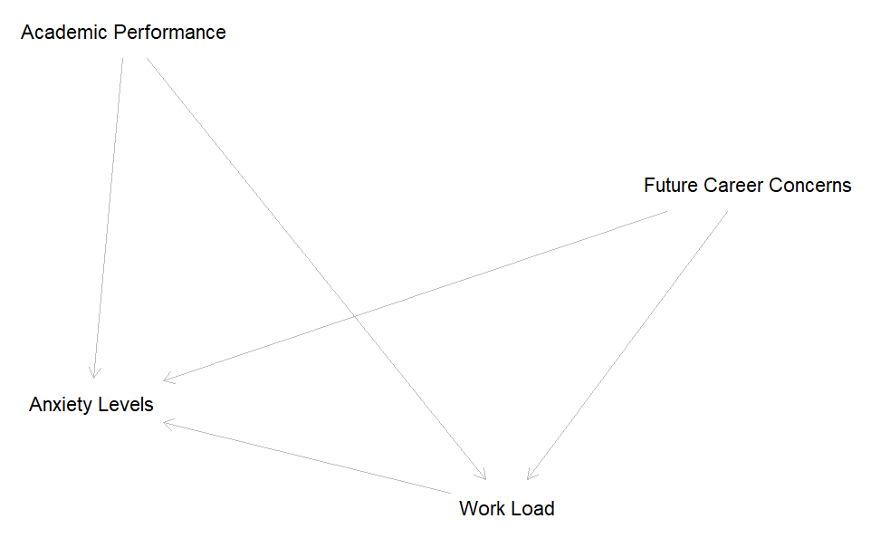

```r
library(dagitty)

# Define your DAG
dag <- dagitty('dag {
  "Work Load" -> "Anxiety Levels"
  "Future Career Concerns" -> "Anxiety Levels"
  "Academic Performance" -> "Anxiety Levels"
    "Future Career Concerns" -> "Work Load"
  "Academic Performance" -> "Work Load"
}')

# Plot the DAG
plot(dag)
```

Outcome: Anxiety Levels (0 to 21) Treatment: Having High Study Load Treatment Effect: Effect of Study Load on Anxiety Levels Treatment Group: Students having high Study Load (Study Load = 3, 4, 5) Control Group: Students having lower study load (Study Load = 0, 1, 2)

## EDA

```r
head(data)
```

|  | anxiety_level | self_esteem | mental_health_history | depression | headache | blood_pressure | sleep_quality | breathing_problem | noise_level | living_conditions | safety | basic_needs | academic_performance | study_load | teacher_student_relationship | future_career_concerns | social_support | peer_pressure | extracurricular_activities | bullying | stress_level |
| --- | --- | --- | --- | --- | --- | --- | --- | --- | --- | --- | --- | --- | --- | --- | --- | --- | --- | --- | --- | --- | --- |
| 1 | 14 | 20 | 0 | 11 | 2 | 1 | 2 | 4 | 2 | 3 | 3 | 2 | 3 | 2 | 3 | 3 | 2 | 3 | 3 | 2 | 1 |
| 2 | 15 | 8 | 1 | 15 | 5 | 3 | 1 | 4 | 3 | 1 | 2 | 2 | 1 | 4 | 1 | 5 | 1 | 4 | 5 | 5 | 2 |
| 3 | 12 | 18 | 1 | 14 | 2 | 1 | 2 | 2 | 2 | 2 | 3 | 2 | 2 | 3 | 3 | 2 | 2 | 3 | 2 | 2 | 1 |
| 4 | 16 | 12 | 1 | 15 | 4 | 3 | 1 | 3 | 4 | 2 | 2 | 2 | 2 | 4 | 1 | 4 | 1 | 4 | 4 | 5 | 2 |
| 5 | 16 | 28 | 0 | 7 | 2 | 3 | 5 | 1 | 3 | 2 | 4 | 3 | 4 | 3 | 1 | 2 | 1 | 5 | 0 | 5 | 1 |
| 6 | 20 | 13 | 1 | 21 | 3 | 3 | 1 | 4 | 3 | 2 | 2 | 1 | 2 | 5 | 2 | 5 | 1 | 4 | 4 | 5 | 2 |

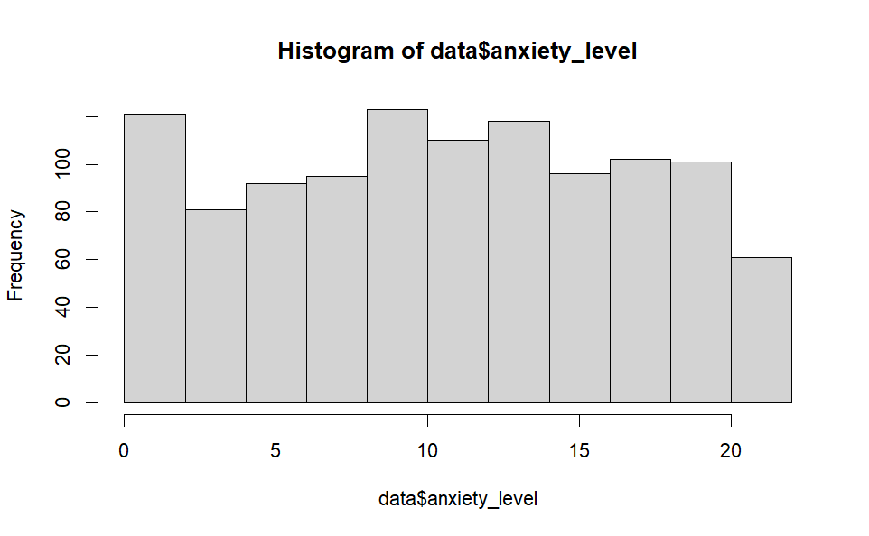

```r
hist(data$anxiety_level)
```

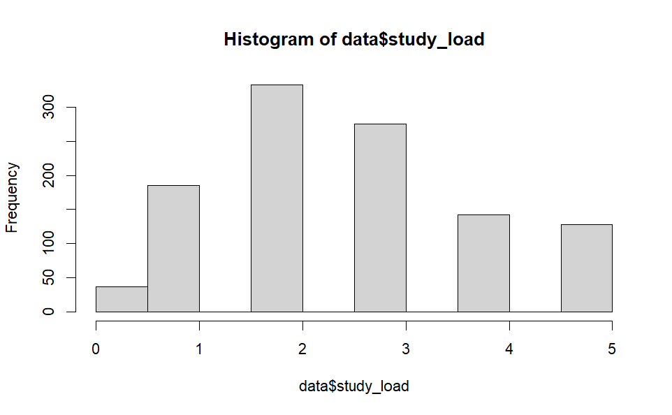

```r
hist(data$study_load)
```

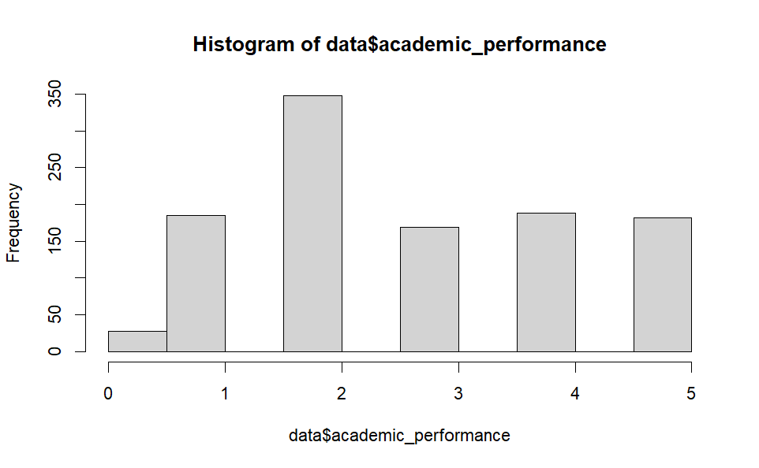

```r
hist(data$academic_performance)
```

```r
# creating variable using mean as threshold for a binary classification of each record.
## TEACHER STUDENT RELATIONSHIP
data<-data%>%
  mutate(teacher_student_relationship_binary=ifelse(teacher_student_relationship<mean(teacher_student_relationship),0,1))%>%
  mutate(teacher_student_relationship_Label = ifelse(teacher_student_relationship_binary==0,"Poor Relationship","Good Relationship"))

# assigning the label based on created binary labels

temp<-data%>%
  group_by(teacher_student_relationship_binary,teacher_student_relationship_Label) %>%
  summarise(Freq=n(), RelFreq = n()/nrow(data))%>%
  dplyr::select(teacher_student_relationship_binary,Freq,RelFreq,teacher_student_relationship_Label)
temp
```

| teacher_student_relationship_binary | Freq | RelFreq | teacher_student_relationship_Label |
| --- | --- | --- | --- |
| 0 | 585 | 0.5318182 | Poor Relationship |
| 1 | 515 | 0.4681818 | Good Relationship |

```r
NA
NA
```

The split is relatively even.

```r
# creating variable using mean as threshold for a binary classification of each record.
## EXTRACURRICULAR ACTIVITIES
data <- data %>%
  mutate(extracurricular_activities_binary = ifelse(extracurricular_activities < mean(extracurricular_activities), 0, 1)) %>%
  mutate(extracurricular_activities_Label = ifelse(extracurricular_activities_binary == 0, "Few Activities", "Many Activities"))

temp <- data %>%
  group_by(extracurricular_activities_binary, extracurricular_activities_Label) %>%
  summarise(Freq = n(), RelFreq = n() / nrow(data)) %>%
  dplyr::select(extracurricular_activities_binary, Freq, RelFreq, extracurricular_activities_Label)
temp
```

| extracurricular_activities_binary | Freq | RelFreq | extracurricular_activities_Label |
| --- | --- | --- | --- |
| 0 | 550 | 0.5 | Few Activities |
| 1 | 550 | 0.5 | Many Activities |

```r
NA
```

```r
# creating variable using mean as threshold for a binary classification of each record.
## FUTURE CAREER CONCERNS
data <- data %>%
  mutate(future_career_concerns_binary = ifelse(future_career_concerns < mean(future_career_concerns), 0, 1)) %>%
  mutate(future_career_concerns_Label = ifelse(future_career_concerns_binary == 0, "Low Concerns", "High Concerns"))

temp <- data %>%
  group_by(future_career_concerns_binary, future_career_concerns_Label) %>%
  summarise(Freq = n(), RelFreq = n() / nrow(data)) %>%
  dplyr::select(future_career_concerns_binary, Freq, RelFreq, future_career_concerns_Label)
temp
```

| future_career_concerns_binary | Freq | RelFreq | future_career_concerns_Label |
| --- | --- | --- | --- |
| 0 | 556 | 0.5054545 | Low Concerns |
| 1 | 544 | 0.4945455 | High Concerns |

```r
NA
```

```r
# creating variable using mean as threshold for a binary classification of each record.
## ACADEMIC PERFORMANCE
data <- data %>%
  mutate(academic_performance_binary = ifelse(academic_performance < mean(academic_performance), 0, 1)) %>%
  mutate(academic_performance_Label = ifelse(academic_performance_binary == 0, "Low Performance", "High Performance"))

temp <- data %>%
  group_by(academic_performance_binary, academic_performance_Label) %>%
  summarise(Freq = n(), RelFreq = n() / nrow(data)) %>%
  dplyr::select(academic_performance_binary, Freq, RelFreq, academic_performance_Label)
temp
```

| academic_performance_binary | Freq | RelFreq | academic_performance_Label |
| --- | --- | --- | --- |
| 0 | 561 | 0.51 | Low Performance |
| 1 | 539 | 0.49 | High Performance |

```r
NA
```

```r
# creating variable using mean as threshold for a binary classification of each record.
## ANXIETY LEVEL
data<-data%>%
  mutate(anxiety_category=ifelse(anxiety_level>mean(anxiety_level),1,0))%>%
  mutate(AnxietyLabel = ifelse(anxiety_category==1,"High","Low"))



temp<-data%>%
  group_by(anxiety_category,AnxietyLabel) %>%
  summarise(Freq=n(), RelFreq = n()/nrow(data))%>%
  dplyr::select(anxiety_category,Freq,RelFreq,AnxietyLabel)
temp
```

| anxiety_category | Freq | RelFreq | AnxietyLabel |
| --- | --- | --- | --- |
| 0 | 566 | 0.5145455 | Low |
| 1 | 534 | 0.4854545 | High |

## Performing RCT

Comparing Academic Performance densities by treatment status after simple_ra

```r
# SIMPLE_RA APPLIED.
set.seed(123)
data.RCT<-data %>%
mutate(treat.simple=simple_ra(N=nrow(data)))%>%
mutate(TreatLabel =
ifelse(treat.simple==1,"Treated","UnTreated"))
head(data.RCT)
```

|  | anxiety_level | self_esteem | mental_health_history | depression | headache | blood_pressure | sleep_quality | breathing_problem | noise_level | living_conditions | safety | basic_needs | academic_performance | study_load | teacher_student_relationship | future_career_concerns | social_support | peer_pressure | extracurricular_activities | bullying | stress_level | teacher_student_relationship_binary | teacher_student_relationship_Label | extracurricular_activities_binary | extracurricular_activities_Label | future_career_concerns_binary | future_career_concerns_Label | academic_performance_binary | academic_performance_Label | … |
| --- | --- | --- | --- | --- | --- | --- | --- | --- | --- | --- | --- | --- | --- | --- | --- | --- | --- | --- | --- | --- | --- | --- | --- | --- | --- | --- | --- | --- | --- | --- |
| 1 | 14 | 20 | 0 | 11 | 2 | 1 | 2 | 4 | 2 | 3 | 3 | 2 | 3 | 2 | 3 | 3 | 2 | 3 | 3 | 2 | 1 | 1 | Good Relationship | 1 | Many Activities | 1 | High Concerns | 1 | High Performance | … |
| 2 | 15 | 8 | 1 | 15 | 5 | 3 | 1 | 4 | 3 | 1 | 2 | 2 | 1 | 4 | 1 | 5 | 1 | 4 | 5 | 5 | 2 | 0 | Poor Relationship | 1 | Many Activities | 1 | High Concerns | 0 | Low Performance | … |
| 3 | 12 | 18 | 1 | 14 | 2 | 1 | 2 | 2 | 2 | 2 | 3 | 2 | 2 | 3 | 3 | 2 | 2 | 3 | 2 | 2 | 1 | 1 | Good Relationship | 0 | Few Activities | 0 | Low Concerns | 0 | Low Performance | … |
| 4 | 16 | 12 | 1 | 15 | 4 | 3 | 1 | 3 | 4 | 2 | 2 | 2 | 2 | 4 | 1 | 4 | 1 | 4 | 4 | 5 | 2 | 0 | Poor Relationship | 1 | Many Activities | 1 | High Concerns | 0 | Low Performance | … |
| 5 | 16 | 28 | 0 | 7 | 2 | 3 | 5 | 1 | 3 | 2 | 4 | 3 | 4 | 3 | 1 | 2 | 1 | 5 | 0 | 5 | 1 | 0 | Poor Relationship | 0 | Few Activities | 0 | Low Concerns | 1 | High Performance | … |
| 6 | 20 | 13 | 1 | 21 | 3 | 3 | 1 | 4 | 3 | 2 | 2 | 1 | 2 | 5 | 2 | 5 | 1 | 4 | 4 | 5 | 2 | 0 | Poor Relationship | 1 | Many Activities | 1 | High Concerns | 0 | Low Performance | … |

```r
tbl<-table(data.RCT$TreatLabel)
prop.table(tbl)
```

```
  Treated UnTreated
0.4909091 0.5090909
```

The split is relatively even.

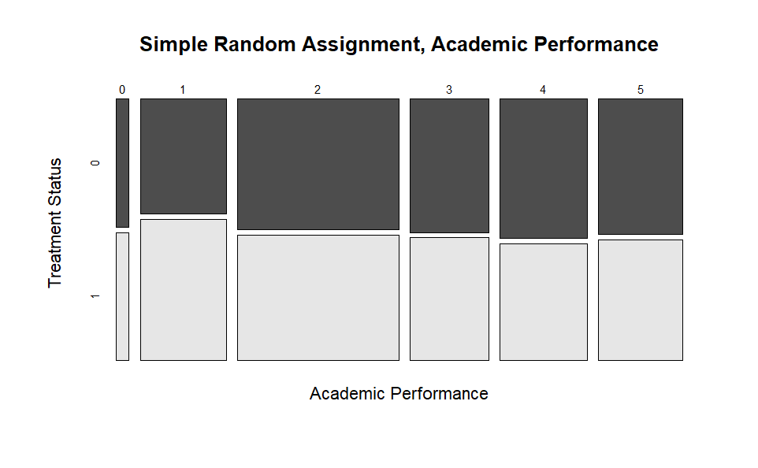

```r
#MOSAIC PLOT FOR ASSESSING SPLIT
ContingencyTable <- table(data.RCT$academic_performance, data.RCT$treat.simple)
mosaicplot(ContingencyTable,
color = TRUE,
xlab = "Academic Performance", # label for x-axis
ylab = "Treatment Status", # label for y-axis
main = "Simple Random Assignment, Academic Performance"
)
```

The mosaic plot shows the even splits across the various levels of academic performance.

```r
# CONDUCTING KS TEST FOR COMPARING COVARIATE DENSITIES
treated<-data.RCT%>% filter(treat.simple==1)
untreated<-data.RCT%>% filter(treat.simple==0)
ks.test(treated$academic_performance,untreated$academic_performance)
```

```
    Asymptotic two-sample Kolmogorov-Smirnov test

data:  treated$academic_performance and untreated$academic_performance
D = 0.042196, p-value = 0.7119
alternative hypothesis: two-sided
```

The large p-Value implies that we fail to reject the null hypothesis, implying that density of academic performance among the treated group is the same as those in the untreated group. That’s a good sign that our RCT will work.

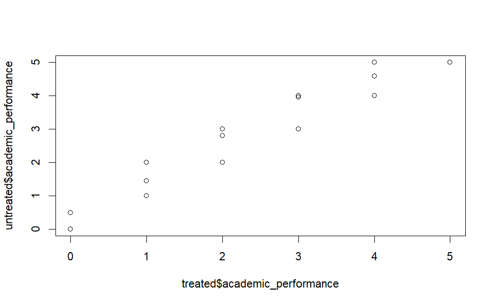

```r
# QQ PLOT FOR VISUAL CONFIRMATION OF DENSITIES
qqplot(treated$academic_performance,untreated$academic_performance)
```

The qqplot is visual confirmation of the density test. The near perfect 45 degree line in the plot implies that the academic performance densities of the treated/untreated overlap substantially.

```r
tbl<-table(data.RCT$TreatLabel,data.RCT$academic_performance_Label)
prop.table(tbl,margin=1)
```

```
            High Performance Low Performance
  Treated          0.4685185       0.5314815
  UnTreated        0.5107143       0.4892857
```

```r
prop.test(tbl)
```

```
    2-sample test for equality of proportions with continuity correction

data:  tbl
X-squared = 1.7935, df = 1, p-value = 0.1805
alternative hypothesis: two.sided
95 percent confidence interval:
 -0.10305312  0.01866158
sample estimates:
   prop 1    prop 2
0.4685185 0.5107143
```

```r
simple.treated<-data.RCT%>%
filter(treat.simple==1)%>%
dplyr::select(anxiety_level)
simple.control<-data.RCT%>%
filter(treat.simple==0)%>%
dplyr::select(anxiety_level)
TE.DiM = mean(simple.treated$anxiety_level)-mean(simple.control$anxiety_level)
TE.DiM
```

```
[1] 0.09689153
```

The estimate of 0.096 implies that with the increase in study load, anxiety increases by 0.096 units.

```r
t.test(simple.control$anxiety_level,simple.treated$anxiety_level)
```

```
    Welch Two Sample t-test

data:  simple.control$anxiety_level and simple.treated$anxiety_level
t = -0.26277, df = 1097.5, p-value = 0.7928
alternative hypothesis: true difference in means is not equal to 0
95 percent confidence interval:
 -0.8203960  0.6266129
sample estimates:
mean of x mean of y
 11.01607  11.11296
```

Large P-Value and 95% CI includes 0, hence we do not have confidence in our results.

```r
TE.OLS<-lm(anxiety_level~treat.simple,data = data.RCT)
summary(TE.OLS)
```

```
Call:
lm(formula = anxiety_level ~ treat.simple, data = data.RCT)

Residuals:
     Min       1Q   Median       3Q      Max
-11.1130  -5.0161  -0.0161   4.9839   9.9839

Coefficients:
             Estimate Std. Error t value Pr(>|t|)
(Intercept)  11.01607    0.25862  42.595   <2e-16 ***
treat.simple  0.09689    0.36912   0.262    0.793
---
Signif. codes:  0 ‘***’ 0.001 ‘**’ 0.01 ‘*’ 0.05 ‘.’ 0.1 ‘ ’ 1

Residual standard error: 6.12 on 1098 degrees of freedom
Multiple R-squared:  6.275e-05, Adjusted R-squared:  -0.0008479
F-statistic: 0.0689 on 1 and 1098 DF,  p-value: 0.793
```

Computing TE via Regression also produces a large p-value and our estimate is insignificant.

## RA+MATCHING

```r
# creating variable using mean as threshold for a binary classification of each record.
## STUDY LOAD
data <- data %>%
  mutate(study_load_binary = ifelse(study_load < mean(study_load), 0, 1)) %>%
  mutate(study_load_label = ifelse(study_load_binary == 0, "Low Study Load", "High Study Load"))

# Create a summary table for study_load
temp_study_load <- data %>%
  group_by(study_load_binary, study_load_label) %>%
  summarise(Freq = n(), RelFreq = n() / nrow(data)) %>%
  dplyr::select(study_load_binary, Freq, RelFreq, study_load_label)
temp_study_load
```

| study_load_binary | Freq | RelFreq | study_load_label |
| --- | --- | --- | --- |
| 0 | 555 | 0.5045455 | Low Study Load |
| 1 | 545 | 0.4954545 | High Study Load |

The split is relatively even

```r
matches.NN.All <- matchit(study_load_binary ~ academic_performance,
                           method = "nearest",
                           distance = "mahalanobis",
                           data = data,
                           ratio = 1)

summary(matches.NN.All)
```

```
Call:
matchit(formula = study_load_binary ~ academic_performance, data = data,
    method = "nearest", distance = "mahalanobis", ratio = 1)

Summary of Balance for All Data:
                     Means Treated Means Control Std. Mean Diff. Var. Ratio eCDF Mean eCDF Max
academic_performance         1.967         3.564         -1.6219     0.5534    0.2696   0.5311

Summary of Balance for Matched Data:
                     Means Treated Means Control Std. Mean Diff. Var. Ratio eCDF Mean eCDF Max
academic_performance         1.967        3.5376         -1.5952     0.5555    0.2654   0.5266
                     Std. Pair Dist.
academic_performance          1.6511

Sample Sizes:
          Control Treated
All           555     545
Matched       545     545
Unmatched      10       0
Discarded       0       0
```

```r
matched.NN.All <- match.data(matches.NN.All)
head(matches.NN.All$match.matrix)
```

```
  [,1]
2 "14"
3 "10"
4 "37"
5 "15"
6 "52"
8 "115"
```

Although high number of matches, the quality of matches is poor. Std Mean Diff should have an absolute value of less than 0.1. The Var Ratio should be close to 1 and the eCDF Mean and Max should be close to 0. This suggests that for a better quality match we may need to use a caliper for this covariate.

```r
## IMPLEMENTING CALIPER ON ACADEMIC PERFORMANCE

matches.NN.All <- matchit(study_load_binary ~ academic_performance,
                           method = "nearest",
                           distance = "mahalanobis",
                           data = data,
                          caliper = c(academic_performance=.3), std.caliper = TRUE,
                           ratio = 1)

summary(matches.NN.All)
```

```
Call:
matchit(formula = study_load_binary ~ academic_performance, data = data,
    method = "nearest", distance = "mahalanobis", caliper = c(academic_performance = 0.3),
    std.caliper = TRUE, ratio = 1)

Summary of Balance for All Data:
                     Means Treated Means Control Std. Mean Diff. Var. Ratio eCDF Mean eCDF Max
academic_performance         1.967         3.564         -1.6219     0.5534    0.2696   0.5311

Summary of Balance for Matched Data:
                     Means Treated Means Control Std. Mean Diff. Var. Ratio eCDF Mean eCDF Max
academic_performance        2.5516        2.5516               0          1         0        0
                     Std. Pair Dist.
academic_performance               0

Sample Sizes:
          Control Treated
All           555     545
Matched       252     252
Unmatched     303     293
Discarded       0       0
```

```r
matched.NN.All <- match.data(matches.NN.All)
head(matches.NN.All$match.matrix)
```

[output not shown]

Although the number of matches have reduced, the quality of matches are good, so we will continue with these matches.

```r
model.OLS.matched<-lm(anxiety_level ~ study_load+future_career_concerns+academic_performance, data = matched.NN.All)
summary(model.OLS.matched)
```

```
Call:
lm(formula = anxiety_level ~ study_load + future_career_concerns +
    academic_performance, data = matched.NN.All)

Residuals:
     Min       1Q   Median       3Q      Max
-16.9380  -1.7705   0.2303   2.2295  12.5813

Coefficients:
                       Estimate Std. Error t value Pr(>|t|)
(Intercept)              7.6059     0.8009   9.497  < 2e-16 ***
study_load               0.9986     0.1716   5.821 1.05e-08 ***
future_career_concerns   1.2673     0.1719   7.373 6.98e-13 ***
academic_performance    -0.8172     0.1884  -4.337 1.75e-05 ***
---
Signif. codes:  0 ‘***’ 0.001 ‘**’ 0.01 ‘*’ 0.05 ‘.’ 0.1 ‘ ’ 1

Residual standard error: 4.22 on 500 degrees of freedom
Multiple R-squared:  0.2732,    Adjusted R-squared:  0.2688
F-statistic: 62.64 on 3 and 500 DF,  p-value: < 2.2e-16
```

This can be interpreted as, with the increase in study load by 1 unit, anxiety increases by 0.99 units. With the other estimates, we also can observe that with one unit increase in future_career_concerns, anxiety increases by 1.26 units.

Since we expected the effect of study load to be greater than 0.99 units, we suspect there may be some bias.

## Checking for Bias and Need for IV

A simple OLS:

```r
ols = lm(anxiety_level ~ study_load+future_career_concerns+academic_performance, data =data)
summary(ols)
```

```
Call:
lm(formula = anxiety_level ~ study_load + future_career_concerns +
    academic_performance, data = data)

Residuals:
     Min       1Q   Median       3Q      Max
-18.6854  -2.1356   0.1741   2.1984  14.5789

Coefficients:
                       Estimate Std. Error t value Pr(>|t|)
(Intercept)              7.3449     0.5870  12.513  < 2e-16 ***
study_load               0.9226     0.1120   8.236 5.02e-16 ***
future_career_concerns   1.7146     0.1075  15.943  < 2e-16 ***
academic_performance    -1.1693     0.1113 -10.506  < 2e-16 ***
---
Signif. codes:  0 ‘***’ 0.001 ‘**’ 0.01 ‘*’ 0.05 ‘.’ 0.1 ‘ ’ 1

Residual standard error: 3.878 on 1096 degrees of freedom
Multiple R-squared:  0.5993,    Adjusted R-squared:  0.5982
F-statistic: 546.3 on 3 and 1096 DF,  p-value: < 2.2e-16
```

We get an estimate of 0.92.

Now, let’s run an IV regression of anxiety on study load using extra curriculars as an instrument.

```r
iv = ivreg(anxiety_level ~ study_load | extracurricular_activities, data = data)
summary(iv)
```

```
Call:
ivreg(formula = anxiety_level ~ study_load | extracurricular_activities,
    data = data)

Residuals:
     Min       1Q   Median       3Q      Max
-24.1037  -3.1373   0.1043   3.8291  24.3123

Coefficients:
            Estimate Std. Error t value Pr(>|t|)
(Intercept)  -3.3123     0.7045  -4.702 2.91e-06 ***
study_load    5.4832     0.2592  21.151  < 2e-16 ***
---
Signif. codes:  0 ‘***’ 0.001 ‘**’ 0.01 ‘*’ 0.05 ‘.’ 0.1 ‘ ’ 1

Residual standard error: 6.146 on 1098 degrees of freedom
Multiple R-Squared: -0.008504,  Adjusted R-squared: -0.009423
Wald test: 447.4 on 1 and 1098 DF,  p-value: < 2.2e-16
```

There is likely OVB. Other factors than future career concerns could affect anxiety levels such as personality traits, family pressures and ambition. Thus, we choose extra curricular activities as a suitable instrument since theoretically it is relevant, independent and exclusive.

```r
iv.FirstStage = lm(study_load~extracurricular_activities, data = data)
iv.ReducedForm = lm(anxiety_level~extracurricular_activities, data = data)
iv.manual = iv.ReducedForm$coefficients[2]/iv.FirstStage$coefficients[2]
iv.manual
```

```
extracurricular_activities
                   5.48319
```

```r
cor(data$study_load, data$extracurricular_activities)
```

```
[1] 0.5435431
```

0.54 seems large enough of a correlation to suggest that extra curriculars is a relevant instrument.

```r
summary(iv, diagnostic = TRUE)
```

```
Call:
ivreg(formula = anxiety_level ~ study_load | extracurricular_activities,
    data = data)

Residuals:
     Min       1Q   Median       3Q      Max
-24.1037  -3.1373   0.1043   3.8291  24.3123

Coefficients:
            Estimate Std. Error t value Pr(>|t|)
(Intercept)  -3.3123     0.7045  -4.702 2.91e-06 ***
study_load    5.4832     0.2592  21.151  < 2e-16 ***

Diagnostic tests:
                  df1  df2 statistic p-value
Weak instruments    1 1098     460.4  <2e-16 ***
Wu-Hausman          1 1097     318.1  <2e-16 ***
Sargan              0   NA        NA      NA
---
Signif. codes:  0 ‘***’ 0.001 ‘**’ 0.01 ‘*’ 0.05 ‘.’ 0.1 ‘ ’ 1

Residual standard error: 6.146 on 1098 degrees of freedom
Multiple R-Squared: -0.008504,  Adjusted R-squared: -0.009423
Wald test: 447.4 on 1 and 1098 DF,  p-value: < 2.2e-16
```

The small p-value of the weak instrument test suggest that we reject the null. We have confidence that the instrument is valid and thus is related sufficiently to study load. On interpreting the Wu Hausman test, we reject the null due to the small p-value and that we do have an endogeneity problem caused by OVB. This supports our use in IV.

```r
summary(iv.ReducedForm)
```

```
Call:
lm(formula = anxiety_level ~ extracurricular_activities, data = data)

Residuals:
     Min       1Q   Median       3Q      Max
-17.2402  -2.7074   0.5262   2.5916  17.5916

Coefficients:
                           Estimate Std. Error t value Pr(>|t|)
(Intercept)                 3.40836    0.31077   10.97   <2e-16 ***
extracurricular_activities  2.76636    0.09996   27.68   <2e-16 ***
---
Signif. codes:  0 ‘***’ 0.001 ‘**’ 0.01 ‘*’ 0.05 ‘.’ 0.1 ‘ ’ 1

Residual standard error: 4.698 on 1098 degrees of freedom
Multiple R-squared:  0.4109,    Adjusted R-squared:  0.4104
F-statistic: 765.9 on 1 and 1098 DF,  p-value: < 2.2e-16
```

Using the reduced form, we observe that the direct effects of the instrument on the outcome is detected as well as the indirect effect on the treatment variable of study load. If the instrument was not related to the outcome of anxiety then the instrument would not be relevant.

```r
summary(iv, diagnostic = TRUE)
```

```
Call:
ivreg(formula = anxiety_level ~ study_load | extracurricular_activities,
    data = data)

Residuals:
     Min       1Q   Median       3Q      Max
-24.1037  -3.1373   0.1043   3.8291  24.3123

Coefficients:
            Estimate Std. Error t value Pr(>|t|)
(Intercept)  -3.3123     0.7045  -4.702 2.91e-06 ***
study_load    5.4832     0.2592  21.151  < 2e-16 ***

Diagnostic tests:
                  df1  df2 statistic p-value
Weak instruments    1 1098     460.4  <2e-16 ***
Wu-Hausman          1 1097     318.1  <2e-16 ***
Sargan              0   NA        NA      NA
---
Signif. codes:  0 ‘***’ 0.001 ‘**’ 0.01 ‘*’ 0.05 ‘.’ 0.1 ‘ ’ 1

Residual standard error: 6.146 on 1098 degrees of freedom
Multiple R-Squared: -0.008504,  Adjusted R-squared: -0.009423
Wald test: 447.4 on 1 and 1098 DF,  p-value: < 2.2e-16
```

Thus, we arrive at the estimate of 5.48. With an increase in study load, we see a statistically significant effect on anxiety levels, i.e., with a unit increase in study load, anxiety increases by 5.48 units.

```r
## data1 contains the categorical values incremented by 1 in order to ensure there is no value '0' in the set which could cause log(0) to be infinity. This thus allows us to use logarithmic values in the lm() command and get marginal percentage effects.
data1<- data %>%
  mutate_if(is.numeric, function(x) x + 1)
head(data1)
```

|  | anxiety_level | self_esteem | mental_health_history | depression | headache | blood_pressure | sleep_quality | breathing_problem | noise_level | living_conditions | safety | basic_needs | academic_performance | study_load | teacher_student_relationship | future_career_concerns | social_support | peer_pressure | extracurricular_activities | bullying | stress_level | teacher_student_relationship_binary | teacher_student_relationship_Label | extracurricular_activities_binary | extracurricular_activities_Label | future_career_concerns_binary | future_career_concerns_Label | academic_performance_binary | academic_performance_Label | … |
| --- | --- | --- | --- | --- | --- | --- | --- | --- | --- | --- | --- | --- | --- | --- | --- | --- | --- | --- | --- | --- | --- | --- | --- | --- | --- | --- | --- | --- | --- | --- |
| 1 | 15 | 21 | 1 | 12 | 3 | 2 | 3 | 5 | 3 | 4 | 4 | 3 | 4 | 3 | 4 | 4 | 3 | 4 | 4 | 3 | 2 | 2 | Good Relationship | 2 | Many Activities | 2 | High Concerns | 2 | High Performance | … |
| 2 | 16 | 9 | 2 | 16 | 6 | 4 | 2 | 5 | 4 | 2 | 3 | 3 | 2 | 5 | 2 | 6 | 2 | 5 | 6 | 6 | 3 | 1 | Poor Relationship | 2 | Many Activities | 2 | High Concerns | 1 | Low Performance | … |
| 3 | 13 | 19 | 2 | 15 | 3 | 2 | 3 | 3 | 3 | 3 | 4 | 3 | 3 | 4 | 4 | 3 | 3 | 4 | 3 | 3 | 2 | 2 | Good Relationship | 1 | Few Activities | 1 | Low Concerns | 1 | Low Performance | … |
| 4 | 17 | 13 | 2 | 16 | 5 | 4 | 2 | 4 | 5 | 3 | 3 | 3 | 3 | 5 | 2 | 5 | 2 | 5 | 5 | 6 | 3 | 1 | Poor Relationship | 2 | Many Activities | 2 | High Concerns | 1 | Low Performance | … |
| 5 | 17 | 29 | 1 | 8 | 3 | 4 | 6 | 2 | 4 | 3 | 5 | 4 | 5 | 4 | 2 | 3 | 2 | 6 | 1 | 6 | 2 | 1 | Poor Relationship | 1 | Few Activities | 1 | Low Concerns | 2 | High Performance | … |
| 6 | 21 | 14 | 2 | 22 | 4 | 4 | 2 | 5 | 4 | 3 | 3 | 2 | 3 | 6 | 3 | 6 | 2 | 5 | 5 | 6 | 3 | 1 | Poor Relationship | 2 | Many Activities | 2 | High Concerns | 1 | Low Performance | … |

```r
data1$anxietyln = log(data1$anxiety_level)
data1$study_loadln = log(data1$study_load)
iv = ivreg(anxietyln ~ study_loadln | extracurricular_activities, data = data1)
summary(iv)
```

```
Call:
ivreg(formula = anxietyln ~ study_loadln | extracurricular_activities,
    data = data1)

Residuals:
      Min        1Q    Median        3Q       Max
-3.410957 -0.324679  0.008216  0.368468  3.143242

Coefficients:
             Estimate Std. Error t value Pr(>|t|)
(Intercept)   -0.0522     0.1419  -0.368    0.713
study_loadln   1.9328     0.1155  16.734   <2e-16 ***
---
Signif. codes:  0 ‘***’ 0.001 ‘**’ 0.01 ‘*’ 0.05 ‘.’ 0.1 ‘ ’ 1

Residual standard error: 0.7732 on 1098 degrees of freedom
Multiple R-Squared: -0.1126,    Adjusted R-squared: -0.1136
Wald test:   280 on 1 and 1098 DF,  p-value: < 2.2e-16
```

Looking at it from a marginal percent change, we estimate that with a 1 percentage increase in study load, anxiety increases by nearly 2%.